# Assignment1

Author

Jean(Naien) Li

**BMB**: if you’re going to make an HTML, it’s convenient to use `embed-resources: true` as above (you had `format: pdf` but uploaded an HTML file …)

## preparation for the packages

```r
## BMB set messages=FALSE to remove chaff
library("tidyverse")
library("rgl")
library("splines")
library("performance")
library("see")
library("qqplotr")
library("faraway")
library("patchwork")
library("MASS")
library("ggplot2")
library("GGally")
library("effects")
```

## question 1

Download the data and input and tidy up the dataset with our needs or demands. Therefore, the tidy up condition is n!=NA and gdp!=NA and pop!=NA.

```r
Olympic_dataset<-read.csv("olymp1.csv")
View(Olympic_dataset)
Original_n<-length(Olympic_dataset$team)
Olympic_dataset<-Olympic_dataset[!is.na(Olympic_dataset$n) & !is.na(Olympic_dataset$gdp) & !is.na(Olympic_dataset$pop), ]
n<-length(Olympic_dataset$team)
```

1. As the rules of thumb, with the samoling size is 1623, then the maximum number of predictors is 1623/15= 108. Because the number of variables is 6, according to the type of the response variable, I will pick 1/2 predictor variables for the response variable. And I would like to predict the total medal count.

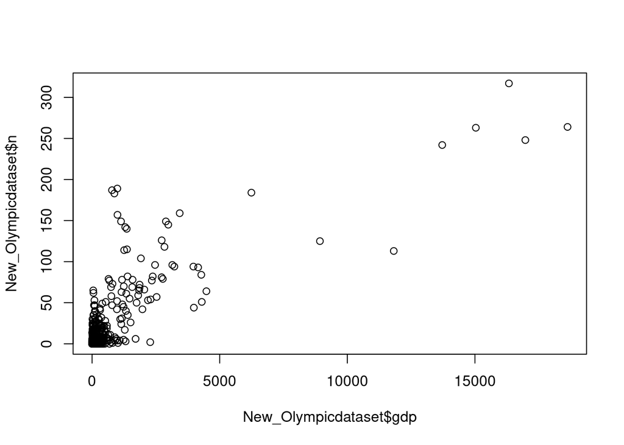

```r
New_Olympicdataset<-Olympic_dataset|>group_by(team, year,gdp,pop)|>summarise(across(n,sum))
plot(New_Olympicdataset$gdp, New_Olympicdataset$n)
```

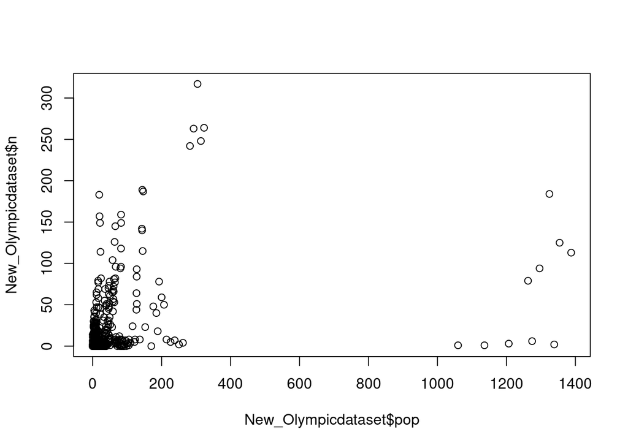

```r
plot(New_Olympicdataset$pop, New_Olympicdataset$n)
```

```r
plot3d(New_Olympicdataset$gdp,New_Olympicdataset$pop,New_Olympicdataset$n)
model_1<-lm(New_Olympicdataset$n~New_Olympicdataset$gdp+New_Olympicdataset$pop)
summary(model_1)
```

```
Call:
lm(formula = New_Olympicdataset$n ~ New_Olympicdataset$gdp +
    New_Olympicdataset$pop)

Residuals:
    Min      1Q  Median      3Q     Max
-90.394  -9.507  -8.080   1.495 165.899

Coefficients:
                         Estimate Std. Error t value Pr(>|t|)
(Intercept)             8.9623516  1.0972227   8.168 2.24e-15 ***
New_Olympicdataset$gdp  0.0179452  0.0006436  27.883  < 2e-16 ***
New_Olympicdataset$pop -0.0127290  0.0066452  -1.916    0.056 .
---
Signif. codes:  0 '***' 0.001 '**' 0.01 '*' 0.05 '.' 0.1 ' ' 1

Residual standard error: 24 on 538 degrees of freedom
Multiple R-squared:  0.6302,    Adjusted R-squared:  0.6289
F-statistic: 458.5 on 2 and 538 DF,  p-value: < 2.2e-16
```

```r
model_2<-lm(New_Olympicdataset$n~New_Olympicdataset$gdp)
summary(model_2)
```

```
Call:
lm(formula = New_Olympicdataset$n ~ New_Olympicdataset$gdp)

Residuals:
     Min       1Q   Median       3Q      Max
-101.165   -9.263   -7.795    1.915  164.836

Coefficients:
                       Estimate Std. Error t value Pr(>|t|)
(Intercept)            8.589201   1.082461   7.935 1.23e-14 ***
New_Olympicdataset$gdp 0.017393   0.000577  30.147  < 2e-16 ***
---
Signif. codes:  0 '***' 0.001 '**' 0.01 '*' 0.05 '.' 0.1 ' ' 1

Residual standard error: 24.06 on 539 degrees of freedom
Multiple R-squared:  0.6277,    Adjusted R-squared:  0.627
F-statistic: 908.8 on 1 and 539 DF,  p-value: < 2.2e-16
```

```r
model_3<-lm(New_Olympicdataset$n~New_Olympicdataset$pop)
summary(model_3)
```

```
Call:
lm(formula = New_Olympicdataset$n ~ New_Olympicdataset$pop)

Residuals:
     Min       1Q   Median       3Q      Max
-106.436  -14.764  -12.757   -1.137  281.183

Coefficients:
                        Estimate Std. Error t value Pr(>|t|)
(Intercept)            14.471545   1.686104   8.583  < 2e-16 ***
New_Olympicdataset$pop  0.070194   0.009284   7.561 1.73e-13 ***
---
Signif. codes:  0 '***' 0.001 '**' 0.01 '*' 0.05 '.' 0.1 ' ' 1

Residual standard error: 37.49 on 539 degrees of freedom
Multiple R-squared:  0.09589,   Adjusted R-squared:  0.09421
F-statistic: 57.17 on 1 and 539 DF,  p-value: 1.734e-13
```

```r
names(New_Olympicdataset)[names(New_Olympicdataset)=="n"]<-"Total_count"
```

We make the plotting between the response variable and the predictors. And create the basic linear regression models, deciding to pick pop variable off from the original model.

2. Now, the response variable is the total number of medal and the presictor variable is gdp. As the R^2 of basic linear model is almost 0.62. Then try to use the different transforming to the predictor or/ and response variable, as well the splines. As the coefficient of the predictor has the small value, as states as a reasonable threshold for a small slope.

```r
sumary(model_2)
```

```
                         Estimate Std. Error t value  Pr(>|t|)
(Intercept)            8.58920105 1.08246154  7.9349 1.227e-14
New_Olympicdataset$gdp 0.01739345 0.00057696 30.1468 < 2.2e-16

n = 541, p = 2, Residual SE = 24.05774, R-Squared = 0.63
```

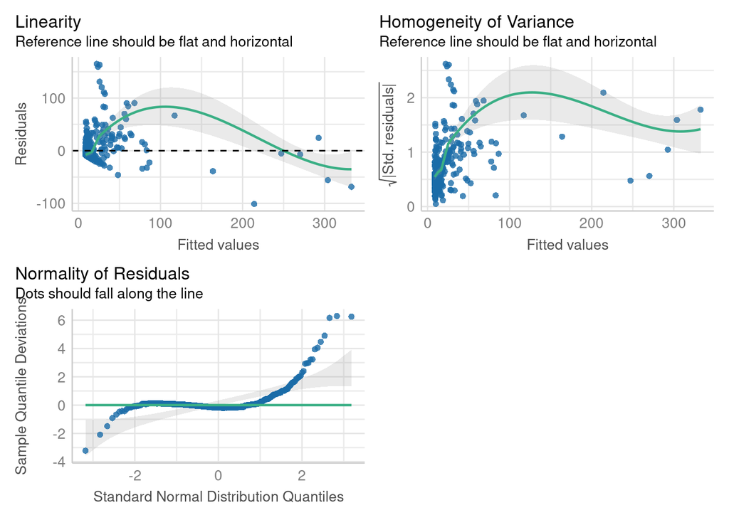

```r
check_model(model_2,check = c("linearity", "homogeneity","outlier", "qq"))
```

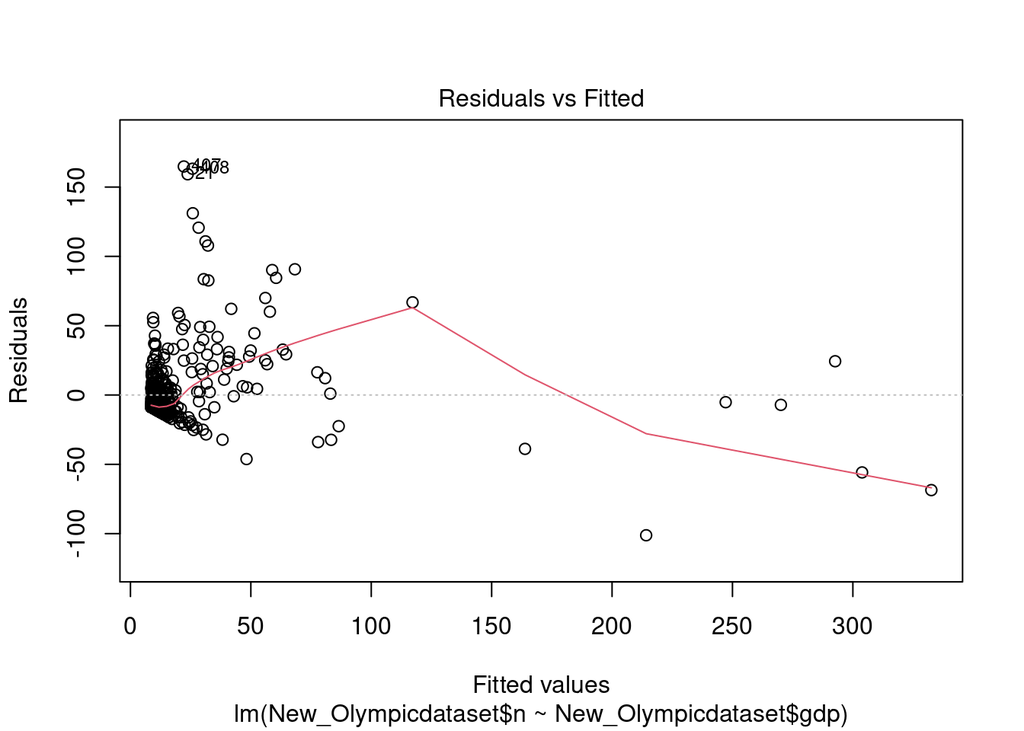

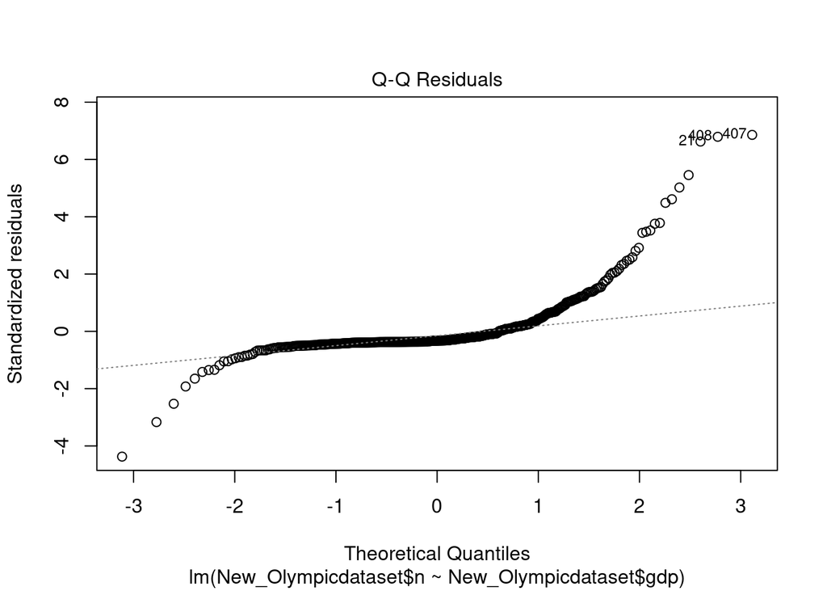

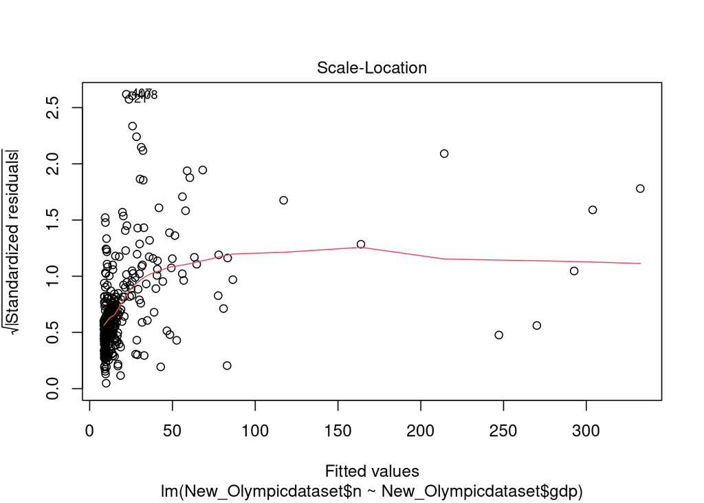

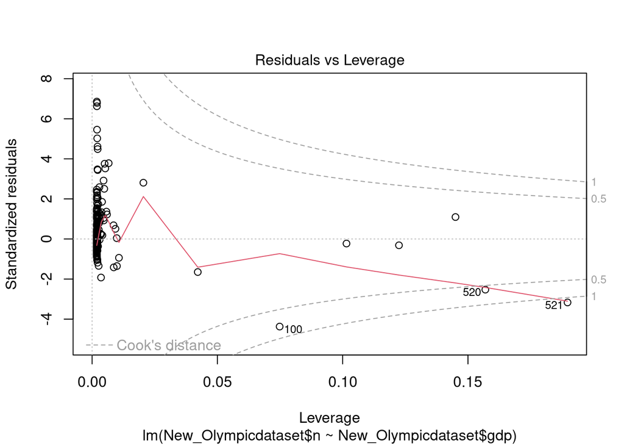

```r
plot(model_2)
```

We draw the graph diagnostics with the linearity, homogeneity, normality(the assumption of the linear model); the outlier(graph by the plot() as the check_model() shows that it can’t display.) Through the graph, the linearity, heteroscedasticity and the non-normality exists the problems, means that we need to try the solution to solve the problems by transformation, like log-transformation, Box-Cox transformation. Besides, we need to consider to drop the values out, by the graph and drop the number of the observation of 100, 520, 521. comment: we don’t calculated by the 4/n threshold and just drop the value by the graph, greater than the 0.5.

```r
New_Olympicdataset<-New_Olympicdataset[-c(100,520,521),]

spline_model<-lm(New_Olympicdataset$Total_count~ns(New_Olympicdataset$gdp,df=5))
summary(spline_model)
```

```
Call:
lm(formula = New_Olympicdataset$Total_count ~ ns(New_Olympicdataset$gdp,
    df = 5))

Residuals:
    Min      1Q  Median      3Q     Max
-75.604  -7.887  -2.882   1.528 157.101

Coefficients:
                                    Estimate Std. Error t value Pr(>|t|)
(Intercept)                           0.5734     3.2720   0.175  0.86094
ns(New_Olympicdataset$gdp, df = 5)1   7.3775     4.5723   1.614  0.10722
ns(New_Olympicdataset$gdp, df = 5)2  11.4200     4.0548   2.816  0.00504 **
ns(New_Olympicdataset$gdp, df = 5)3 183.8980    10.9611  16.777  < 2e-16 ***
ns(New_Olympicdataset$gdp, df = 5)4 233.4224    10.5608  22.103  < 2e-16 ***
ns(New_Olympicdataset$gdp, df = 5)5 271.4758    14.2885  19.000  < 2e-16 ***
---
Signif. codes:  0 '***' 0.001 '**' 0.01 '*' 0.05 '.' 0.1 ' ' 1

Residual standard error: 21.72 on 532 degrees of freedom
Multiple R-squared:  0.6492,    Adjusted R-squared:  0.6459
F-statistic: 196.9 on 5 and 532 DF,  p-value: < 2.2e-16
```

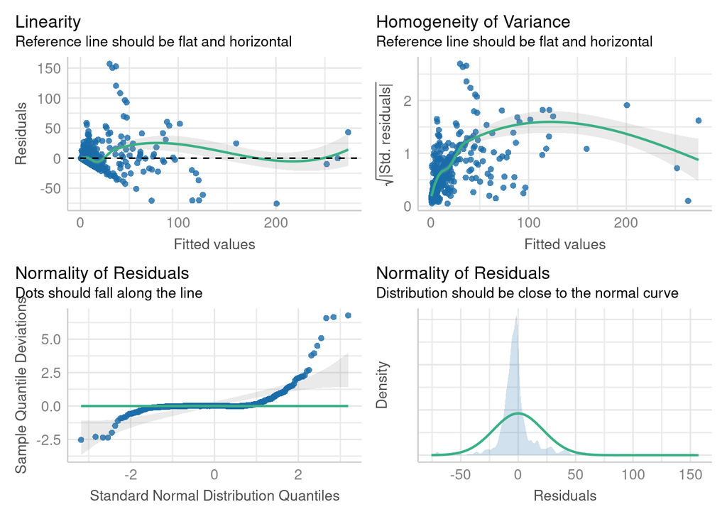

```r
check_model(spline_model)
```

```r
#gdp_limit<-range(New_Olympicdataset$gdp)
#grid<-seq(gdp_limit[1],gdp_limit[2])
#predicts<-predict(spline_model,grid)
#plot(New_Olympicdataset$gdp,New_Olympicdataset$Total_count)
#alines(model_1)
```

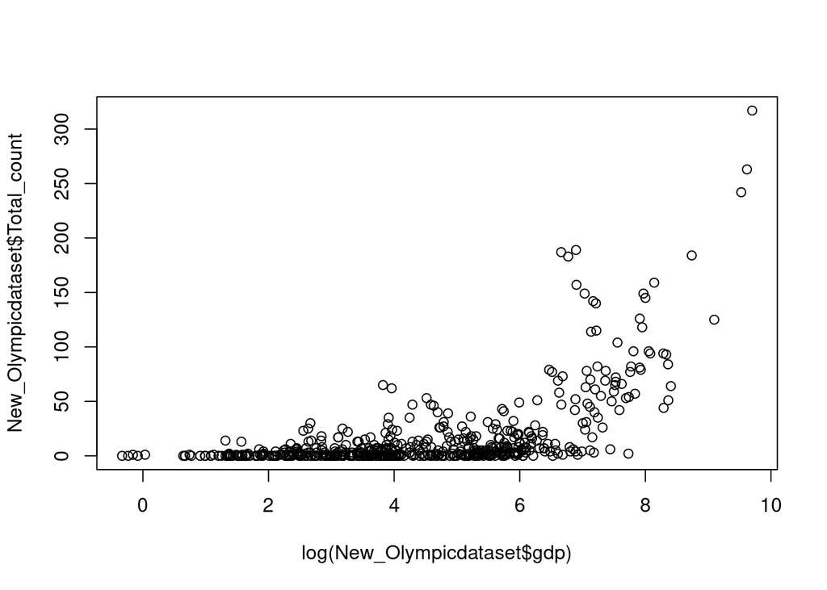

```r
plot(log(New_Olympicdataset$gdp),New_Olympicdataset$Total_count)
```

```r
log_model<-lm(New_Olympicdataset$Total_count~log(New_Olympicdataset$gdp))
summary(log_model)
```

```
Call:
lm(formula = New_Olympicdataset$Total_count ~ log(New_Olympicdataset$gdp))

Residuals:
    Min      1Q  Median      3Q     Max
-50.981 -18.889  -3.864  10.912 242.372

Coefficients:
                            Estimate Std. Error t value Pr(>|t|)
(Intercept)                  -31.961      3.285  -9.729   <2e-16 ***
log(New_Olympicdataset$gdp)   10.988      0.676  16.253   <2e-16 ***
---
Signif. codes:  0 '***' 0.001 '**' 0.01 '*' 0.05 '.' 0.1 ' ' 1

Residual standard error: 29.9 on 536 degrees of freedom
Multiple R-squared:  0.3301,    Adjusted R-squared:  0.3289
F-statistic: 264.2 on 1 and 536 DF,  p-value: < 2.2e-16
```

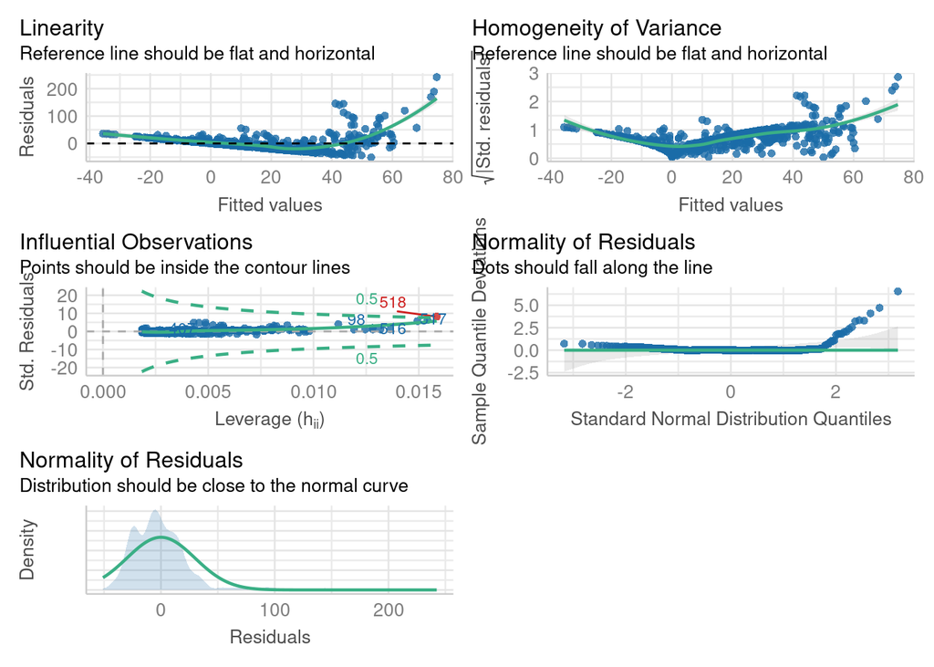

```r
check_model(log_model)
```

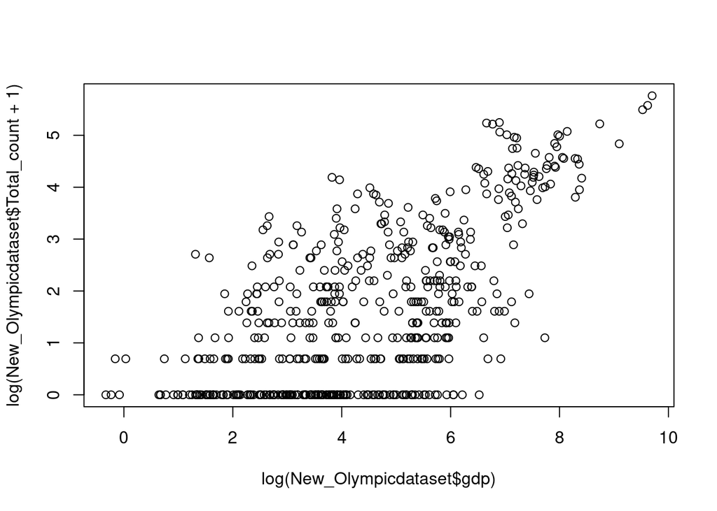

```r
plot(log(New_Olympicdataset$gdp),log(New_Olympicdataset$Total_count+1))
```

```r
log_model2<-lm(log(Total_count+1)~log(gdp),data=New_Olympicdataset)
summary(log_model2)
```

```
Call:
lm(formula = log(Total_count + 1) ~ log(gdp), data = New_Olympicdataset)

Residuals:
     Min       1Q   Median       3Q      Max
-2.71757 -0.94828 -0.03072  0.87370  2.86262

Coefficients:
            Estimate Std. Error t value Pr(>|t|)
(Intercept) -0.63870    0.12706  -5.027 6.81e-07 ***
log(gdp)     0.51436    0.02615  19.673  < 2e-16 ***
---
Signif. codes:  0 '***' 0.001 '**' 0.01 '*' 0.05 '.' 0.1 ' ' 1

Residual standard error: 1.156 on 536 degrees of freedom
Multiple R-squared:  0.4193,    Adjusted R-squared:  0.4182
F-statistic:   387 on 1 and 536 DF,  p-value: < 2.2e-16
```

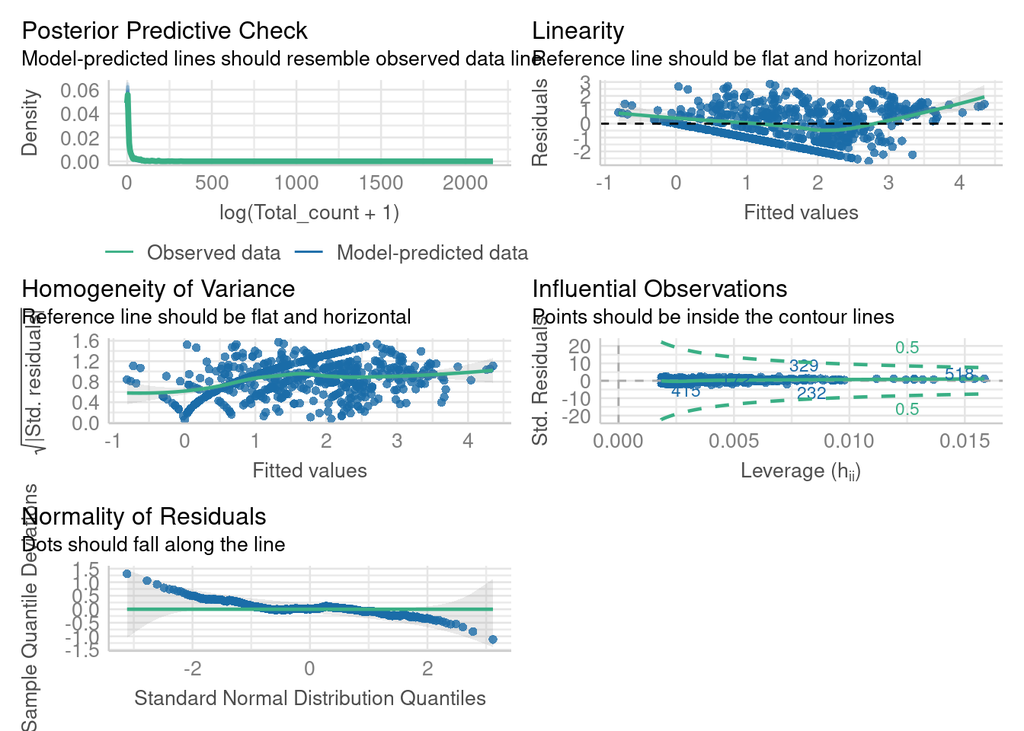

```r
performance::check_model(log_model2)
```

From the fitting model process, we know that the R^2 is lower than the basic linear model with log transformation to predictor and response variable. But the problems has been developed by the log transformation to the response variable and the predictor variable.

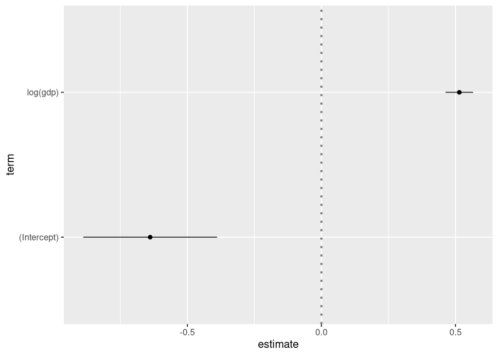

```r
ggcoef(log_model2)
```

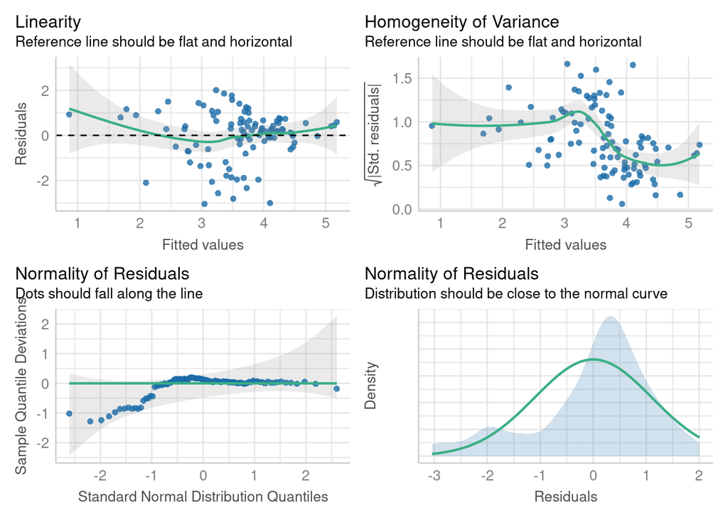

```r
scale_logmodel2<-lm(log(New_Olympicdataset$Total_count+1)~log(scale(New_Olympicdataset$gdp,center = TRUE,scale = FALSE)))
check_model(scale_logmodel2)
```

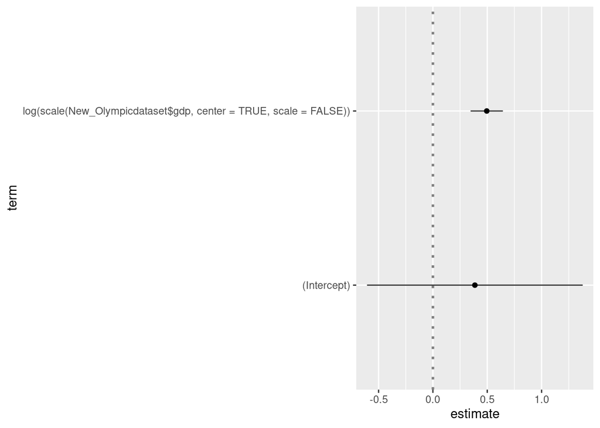

```r
ggcoef(scale_logmodel2)
```

It doesn’t need to do the scale and center to the predictor, because the original coefficient is more clear positive influence to the model.

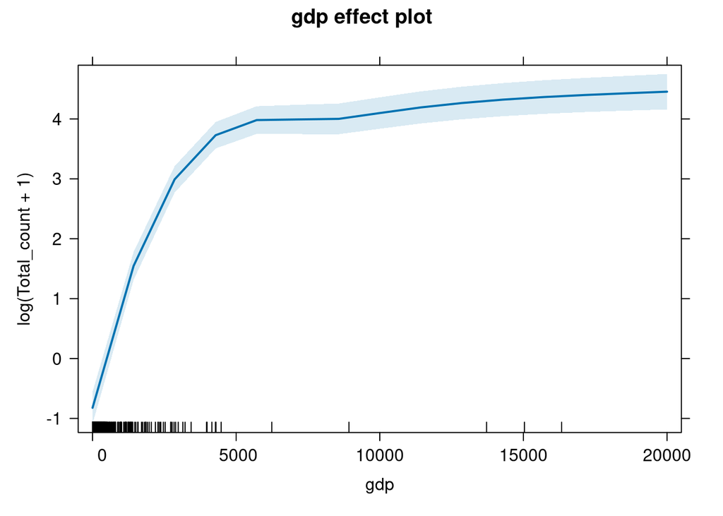

```r
object<-effects::allEffects(log_model2)
plot(object)
```

## question 2

Create the 4*4 daatset and input Comment: set the control group expressed by A; level Ⅰ expressed by B; level Ⅱ expressed by C: level Ⅲ by D

```r
Q2_dataset<-read.csv("Q2.csv")
```

contrasts are between the control group with the average of each level group by the contr.treatment

```r
Q2_dataset$group<-factor(Q2_dataset$group)
contrasts(Q2_dataset$group)<-contr.treatment(levels(Q2_dataset$group))
Q2_model1<-lm(Q2_dataset$result~Q2_dataset$group)
coef(Q2_model1)
```

```
      (Intercept) Q2_dataset$groupB Q2_dataset$groupC Q2_dataset$groupD
              100               -30               -50               -40
```

```r
Q2_dataset$group<-factor(Q2_dataset$group)
contrasts(Q2_dataset$group)<-contr.helmert(levels(Q2_dataset$group))
Q2_model2<-lm(Q2_dataset$result~Q2_dataset$group)
coef(Q2_model2)
```

```
      (Intercept) Q2_dataset$group1 Q2_dataset$group2 Q2_dataset$group3
        70.000000        -15.000000        -11.666667         -3.333333
```

## Question 3

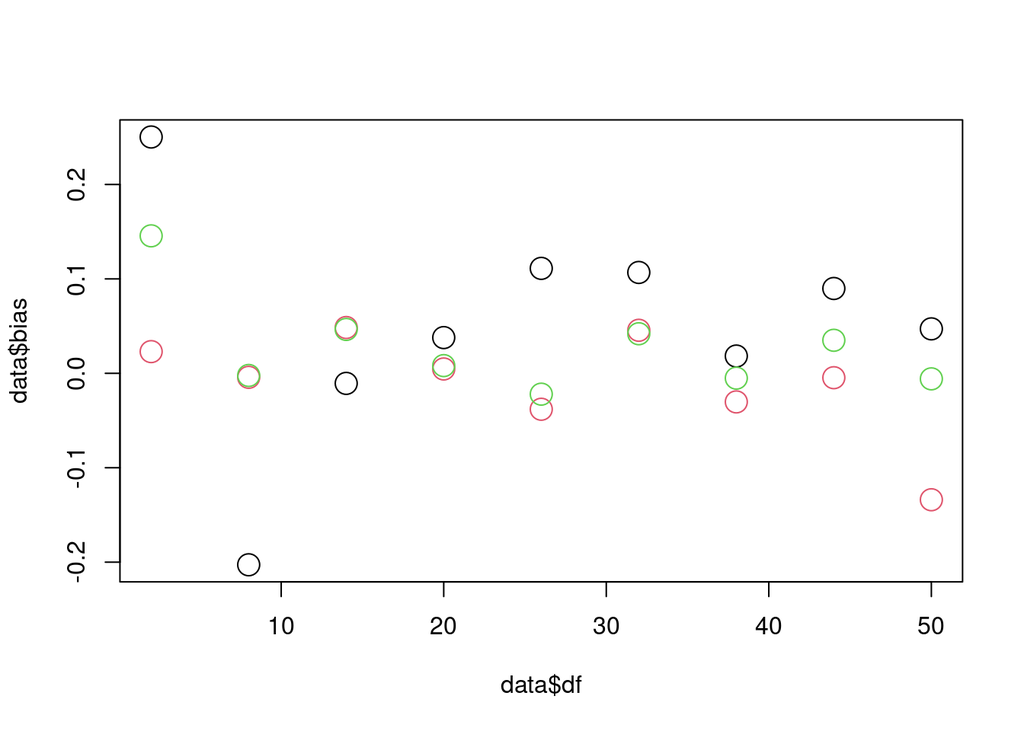

```r
between_num <- function(a, b){ as.numeric(b[1] < a & a < b[2])}

sim_fun <- function(n,df, True_slope, sd = 1, intercept = 0) {
    x <- runif(n)
    y <- (intercept+True_slope*x)+sd*rt(n,df )
    dataset<-data.frame(x, y)
    model<-lm(y~x,data = dataset)
    slope<-coef(model)[2]
    p_value<-coef(summary(model))[2,"Pr(>|t|)"]
    interval<-confint(model)[2,]
    invole<-between_num(True_slope,interval)
    result<-list()
    result$slope<-slope
    result$p_value<-p_value
    result$invole<-invole
    result
}

Simulate_time<-function(time,n,df, True_slope,alpha){
  slope_vec<-rep(0,time)
  P_vector<-rep(0,time)
  coverage_num<-rep(0,time)
  for (i in 1:time) {
    result<-sim_fun(n,df, True_slope, sd = 1, intercept = 0)
    slope_vec[i]<-result$slope
    P_vector[i]<-result$p_value
    coverage_num[i]<-result$invole
  }
  bias<-mean(slope_vec-True_slope)
  standard_error<-sd(slope_vec)
  RMSE<-sqrt(mean((slope_vec-True_slope)^2))
  power<-mean(P_vector[P_vector<alpha])
  Coverage<-mean(coverage_num)
  Result<-list()
  Result$bias<-bias
  Result$RMSE<-RMSE
  Result$power<-power
  Result$Coverage<-Coverage
  Result
}

set.seed(100)
True_slope<-1
time<-100
alpha<-0.05
df<-2
set_n<-c(10,20,100)
data<-data.frame(df=rep(0,27),n=rep(0,27),bias=rep(0,27),RMSE=rep(0,27),power=rep(0,),coverage=rep(0,27))
j<-1
while(df<=50){

  for (i in 1:3 ) {
    n<-set_n[i]
    Result<-Simulate_time(time,n,df,True_slope,alpha)
    data$df[j]<-df
    data$n[j]<-n
    data$bias[j]<-Result$bias
    data$RMSE[j]<-Result$RMSE
    data$power[j]<-Result$power
    data$coverage[j]<-Result$Coverage
    j<-j+1
  }
  df<-df+6
}



plot(data$df,data$bias,col=as.factor(data$n),cex=2,pch=21)
```

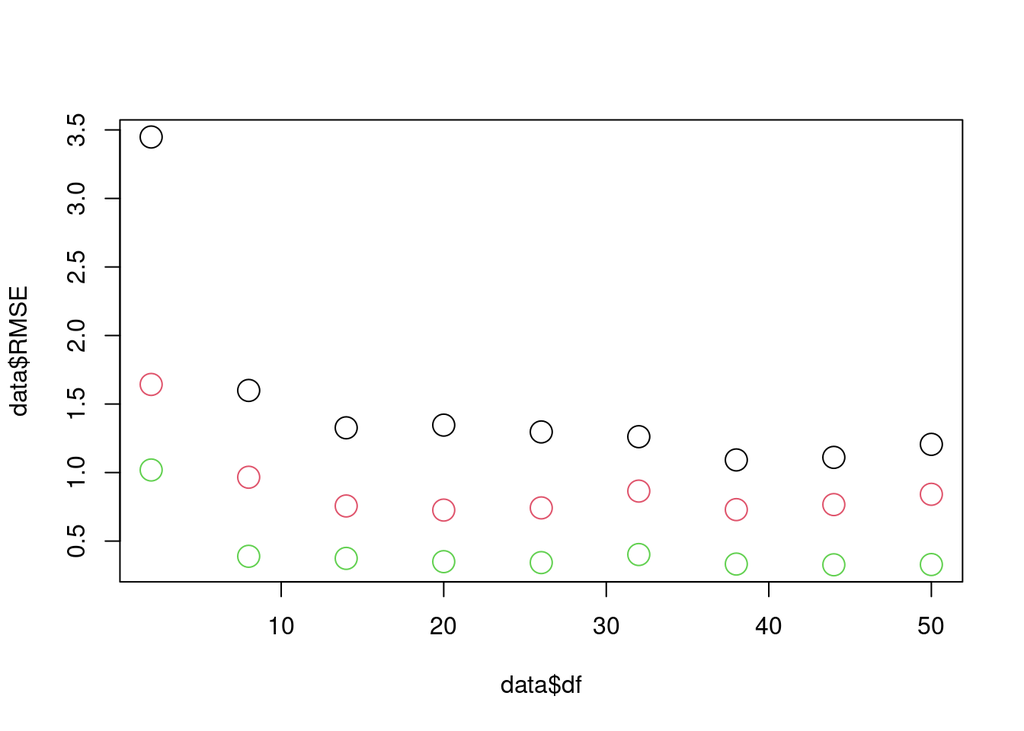

```r
plot(data$df,data$RMSE,col=as.factor(data$n),cex=2,pch=21)
```

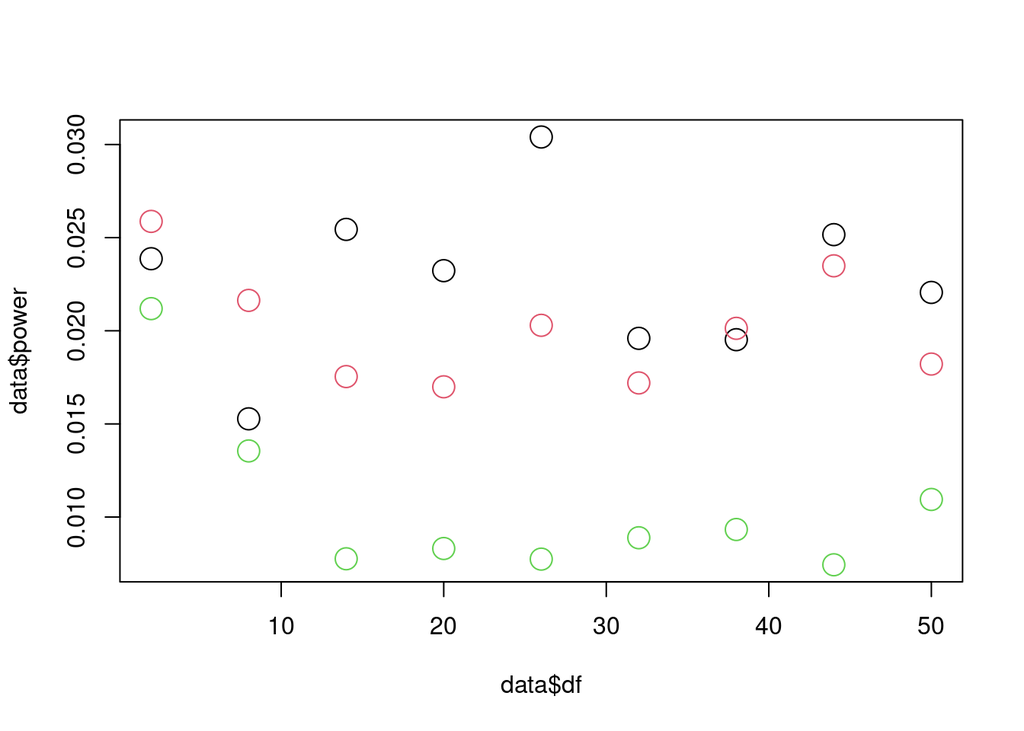

```r
plot(data$df,data$power,col=as.factor(data$n),cex=2,pch=21)
```

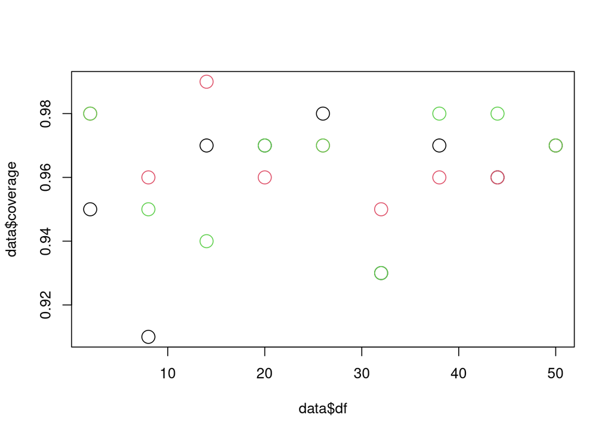

```r
plot(data$df,data$coverage,col=as.factor(data$n),cex=2,pch=21)
```

```r
View(data)
## when I get updated to the R4.4.1 version, I can't use the ggplot to plotting. And now using plot() to create the basic plotting and add the simulation data.
```